# Logistic Regression Problem Set

# 1 NFL Wins

This csv contains points earned by every team in the NFL and whether or not they won (a 1 is a win and a 0 is a loss) from 1984-2014.[^1] We want to build a model to see if we can predict the likelihood a team won its game based solely on the number of points it earned.

## 1.1 Read and Visualize the Data

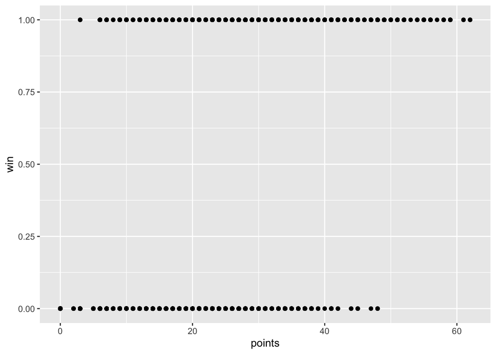

```r
library(tidyverse)

# Read the data
nfl <- read.csv('./nfl_points_wins.csv')

# We can just produce a scatter plot, but this is too much...
ggplot(data = nfl, aes(x = points, y = win)) + geom_point()
```

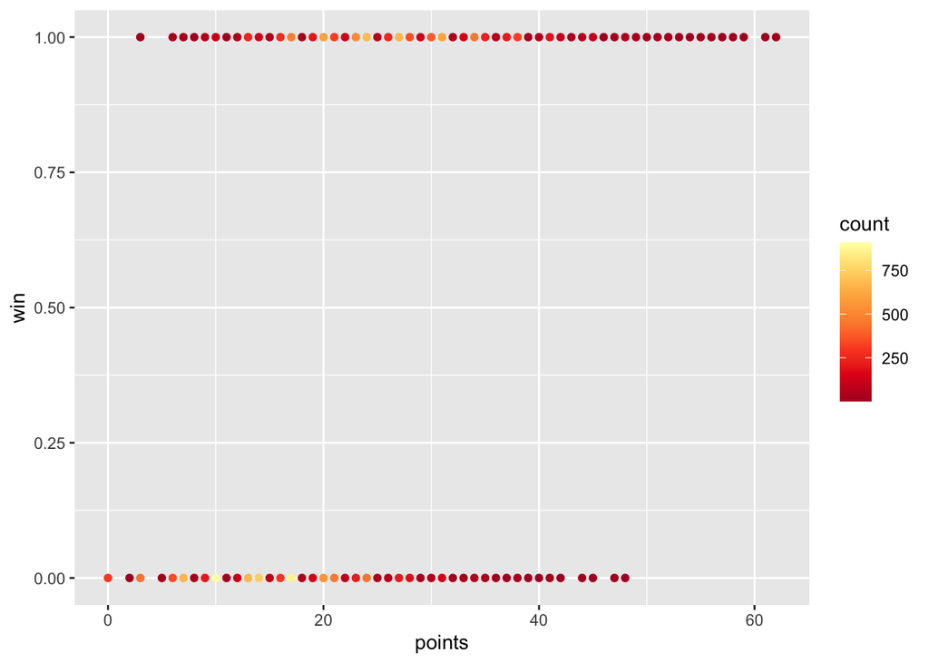

```r
# We can summarize the data and add color based on numbers of wins at each point level
nfl.temp <- nfl %>% group_by(points, win) %>% summarise(count = n())
# We can then plot each of these points and get a better idea of what's going on
ggplot(data = nfl.temp, aes(x = points, y = win, color = count)) +
  geom_point() +
  scale_color_distiller(palette = 'YlOrRd', direction = -1)  # change the color from indecipherable blue
```

```r
# This is still a bit challenging to see (b/c of many outliers...)
# but you can see roughtly speaking, there are lots of losses with low points and lots of wins with high points
```

## 1.2 Model

1. Use a logistic regression to model your data. Interpret your summary results.

```r
# conduct the regression using glm
nfl.glm <- glm(win~points, family = binomial, data = nfl)
summary(nfl.glm)
```

```
##
## Call:
## glm(formula = win ~ points, family = binomial, data = nfl)
##
## Deviance Residuals:
##     Min       1Q   Median       3Q      Max
## -2.9959  -0.7531  -0.1032   0.7838   2.4398
##
## Coefficients:
##             Estimate Std. Error z value Pr(>|z|)
## (Intercept) -3.41739    0.05694  -60.02   <2e-16 ***
## points       0.16445    0.00262   62.76   <2e-16 ***
## ---
## Signif. codes:  0 '***' 0.001 '**' 0.01 '*' 0.05 '.' 0.1 ' ' 1
##
## (Dispersion parameter for binomial family taken to be 1)
##
##     Null deviance: 23866  on 17215  degrees of freedom
## Residual deviance: 17158  on 17214  degrees of freedom
## AIC: 17162
##
## Number of Fisher Scoring iterations: 5
```

```r
# we see both beta_0 and beta_1 are signficant
```

2. Write out the mathematical model.

```
We have beta_0 = -3.4 and beta_1 = .16
```

$$p = \frac{e^{-3.4 + .16x_1}}{1 + e^{-3.4 + .16x_1}}$$

Where $x_1$ are the number of points earned in the game.

3. What does a one point increase indicate in terms of increasing the odds for winning?

```
The odds are:
```

$$\frac{p}{1-p} = e^{-3.4 + .16x_1} = e^{-3.4} \cdot e^{.16x_1}$$

```
We can then say that an increase of one point increases the odds by 17%
```

4. Plot your model with the data.

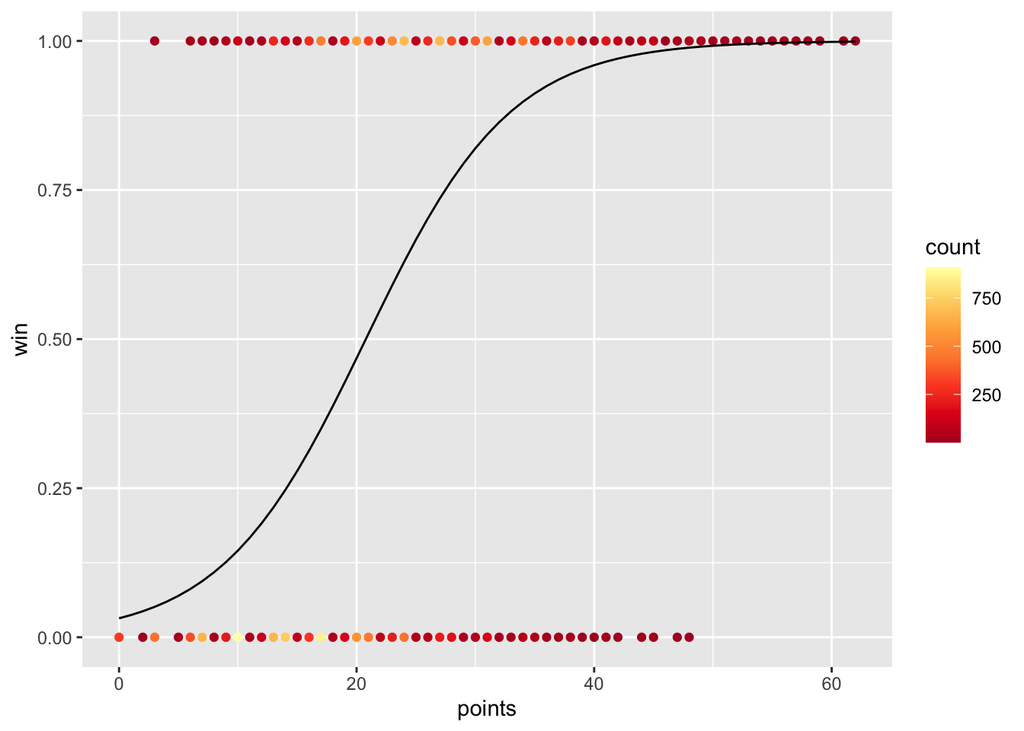

```r
# Get an input data frame with every point possible from 1 to the max points earned
myLine <- data.frame(points= seq(0, max(nfl$points), by = 1))
# Predict the probability
myLine$prob <- predict(nfl.glm, myLine, type = 'response')

ggplot() +
  geom_point(data = nfl.temp, aes(x = points, y = win, color = count)) +
  geom_line(data = myLine, aes(x = points, y = prob)) +
  scale_color_distiller(palette = 'YlOrRd', direction = -1)  # change the color from indecipherable blue
```

```r
# This is somewhat useful - it fits our intuitive sense that you aren't very likely to win
# with only a few points and much more likely to win with many points.
# Of course, it can be hard to see those in between numbers when there are so many results right on top
# of eachother
```

## 1.3 Check Assumptions

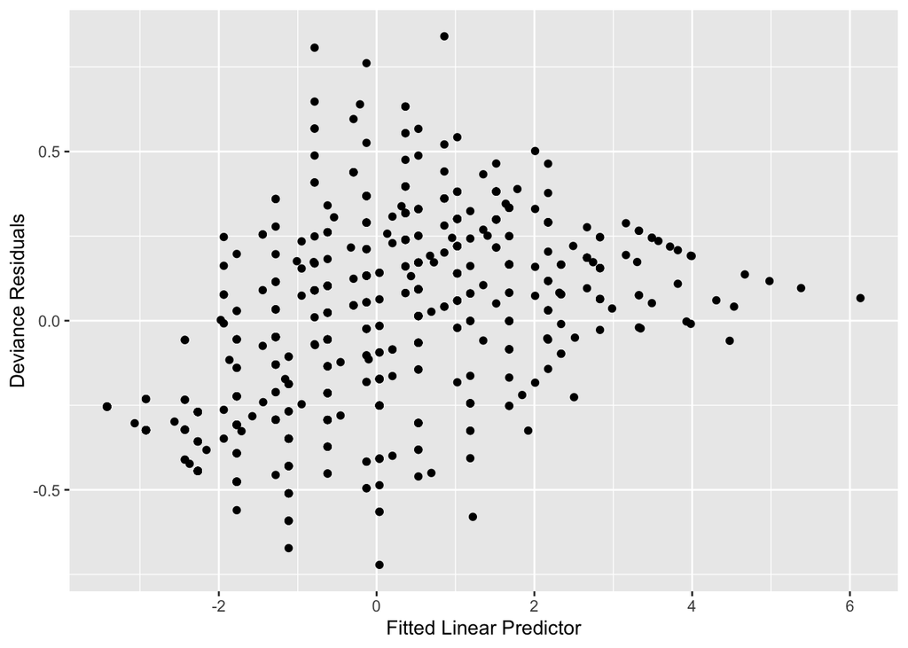

```r
# Create a tibble with the deviance residuals and linear predictors
myChecks <- tibble(resid = residuals(nfl.glm),
                   preds = predict(nfl.glm))

# group into bins of 30
myChecks <- myChecks %>%
   arrange(preds) %>%
   mutate(bin = c(rep(1:573, each = 30), rep(574, nrow(nfl) - 573*30)))

# calculate mean residuals and predictors
myChecks %>% group_by(bin) %>%
   summarize(
     meanResid = mean(resid),
     meanPred = mean(preds)
   ) %>%
  # plot the results
  ggplot() +
  geom_point(aes(x = meanPred, y = meanResid)) +
  xlab('Fitted Linear Predictor') +
  ylab('Deviance Residuals')
```

```r
# The resulting plot looks OK.  There is some overestimation and underestimation at the extremes
# We may see a bit of lack of independence, but hard to say.
# Similarly, we have a higher amount of variance at the middle predictions
# this is to be expected - you're always going to lose if you score 0 points, and almost always going
# to win with sufficiently high points.  The middle level scores are more variable
```

## 1.4 Assess the Fit

1. Calculate the $R^2$ for the model in the two ways provided in the lesson.

$R^2 = \frac{D_{Null} - D}{D_{Null}}$

```r
(nfl.glm$null - nfl.glm$dev) / nfl.glm$null
```

```
## [1] 0.2810935
```

```r
# We eexplain about 28% of the variance in success by the number of points won
```

$R^{2}=\frac{1 - exp\left\{ (D-D_{NULL})/N \right\}} {1 - exp\left\{-D_{NULL}/N \right\}}$

```r
(1-exp( (nfl.glm$dev - nfl.glm$null)/nrow(nfl))) / (1-exp( (- nfl.glm$null)/nrow(nfl)))
```

```
## [1] 0.4303004
```

```r
# We explain about 43% of the variance
```

2. Check the goodness of fit using a Hosmer-Lemeshow test.

```r
library(ResourceSelection)
```

```
## ResourceSelection 0.3-5   2019-07-22
```

```r
p.hat = predict(nfl.glm, type = 'response')
hoslem.test(nfl$win, p.hat)
```

```
##
##  Hosmer and Lemeshow goodness of fit (GOF) test
##
## data:  nfl$win, p.hat
## X-squared = 180.8, df = 8, p-value < 2.2e-16
```

```r
# In this case we reject our null, as it appears that we do not have a good fit
```

```r
nfl2 <- nfl %>%
  # group by the points earned
  group_by(points) %>%
  # calculate number of wins and observations
  summarise(N = n(),
            wins = sum(win)) %>%
  # get the observed probabilities
  mutate(observed = wins/N) %>%
  # get the predicted probabilities
  mutate(expected =  predict(nfl.glm, list(points = points), type = 'response'))

# Calculate the chi squared coefficient
nfl2 %>% mutate(chi = (observed - expected)^2 / expected) %>% summarise(sum(chi))
```

```
## # A tibble: 1 x 1
##   `sum(chi)`
##        <dbl>
## 1      0.687
```

```r
# calculate the critical value at .95
pchisq(.687, df = 58, lower.tail = F)
```

```
## [1] 1
```

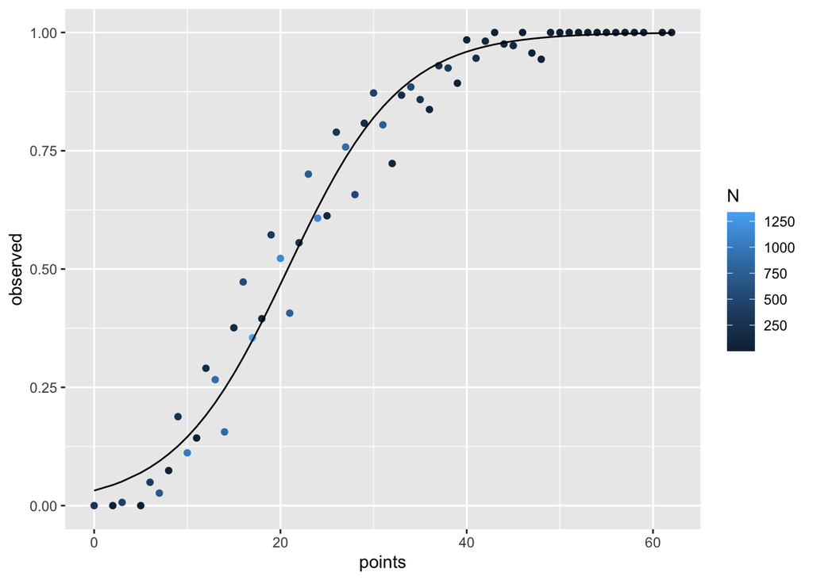

```r
# we have a p-value that is effectively 1, saying this is a good model

# We can also plot our results
ggplot() +
  geom_point(data = nfl2, aes(x = points, y = observed, color = N)) +
  geom_line(data = nfl2, aes(x = points, y = expected))
```

4. Explain why there may be a difference between the Hosmer Test and the Pearson Chi Squared test.

```
You need to compare the assumptions.  Hosmer test assumes small numbers of observations per grouping (meaning you won't get as accurate of an estimate for your probabilities).  We actually had a large number of observations for most points earned, which gives us a reasonable estimate.  This is where things get tricky.
```

# 2 Regression with Multiple Variables

In the tutorial, we modeled coronary heart disease as a function of age using the data set `SAheart` from the package `bestglm`. This data set actually has nine possible regressors: systolic blood pressure, tobacco use, etc…

Note, for this question, we are not going to do the full modeling, simply a few exercises to practice logsitic regression with multiple variables. You are welcome to build the full model, however.

## 2.1 Assess the Data

Can you use all of this data to conduct a logistic regression? Why or why not? (Hint, do a visual check with `pairs`)

```r
library(bestglm)
```

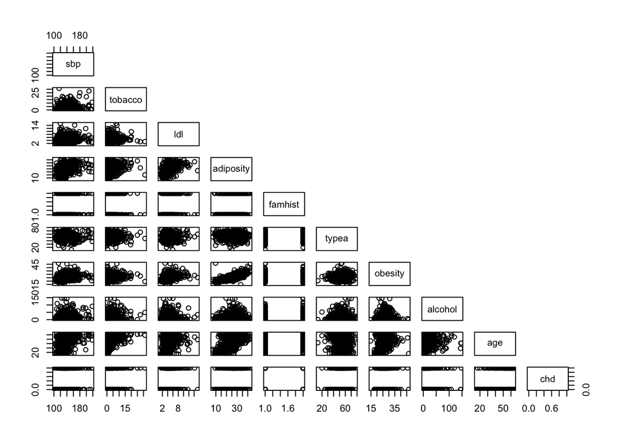

```r
pairs(SAheart, upper.panel = NULL)
```

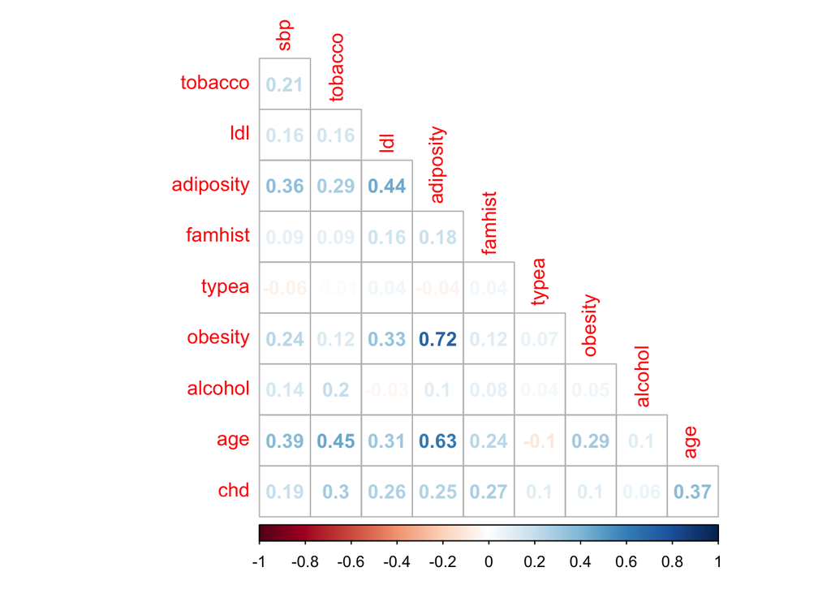

```r
# it appears that there is some collinearity among the various
# possible regressors.  Notably, consider that obesity and adiposity
# are essentially the same thing

# We can also look at correlations using corplot
# Note the data has a factor - famhist, so we have to transform it
myData <- SAheart
myData$famhist <- ifelse(myData$famhist == 'Present', 1, 0)
corrplot::corrplot(cor(myData), method = 'number', type = 'lower', diag = F)
```

## 2.2 Assess Regressors

Conduct a logistic regression to predict coronary heart disease as a function of all the possible regressors (without interactions) (understanding that we may need to actually drop any non-independent regressors). What regressors are significant at $\alpha = .05$? Of these, what has the greatest impact on predicting heart disease?

```r
# We model this in the same way as we have previously
myModel <- glm(chd ~ ., data = SAheart, family = binomial)
summary(myModel)
```

```
##
## Call:
## glm(formula = chd ~ ., family = binomial, data = SAheart)
##
## Deviance Residuals:
##     Min       1Q   Median       3Q      Max
## -1.7781  -0.8213  -0.4387   0.8889   2.5435
##
## Coefficients:
##                  Estimate Std. Error z value Pr(>|z|)
## (Intercept)    -6.1507209  1.3082600  -4.701 2.58e-06 ***
## sbp             0.0065040  0.0057304   1.135 0.256374
## tobacco         0.0793764  0.0266028   2.984 0.002847 **
## ldl             0.1739239  0.0596617   2.915 0.003555 **
## adiposity       0.0185866  0.0292894   0.635 0.525700
## famhistPresent  0.9253704  0.2278940   4.061 4.90e-05 ***
## typea           0.0395950  0.0123202   3.214 0.001310 **
## obesity        -0.0629099  0.0442477  -1.422 0.155095
## alcohol         0.0001217  0.0044832   0.027 0.978350
## age             0.0452253  0.0121298   3.728 0.000193 ***
## ---
## Signif. codes:  0 '***' 0.001 '**' 0.01 '*' 0.05 '.' 0.1 ' ' 1
##
## (Dispersion parameter for binomial family taken to be 1)
##
##     Null deviance: 596.11  on 461  degrees of freedom
## Residual deviance: 472.14  on 452  degrees of freedom
## AIC: 492.14
##
## Number of Fisher Scoring iterations: 5
```

```r
# We see that tobacco use, ldl, family history, type a personality, and age are all signfiicant
# Family history has the greatest impact (note the coefficient)
```

[^1]: Much thanks to Ian Kloo for scraping this data.